## Simulating P-values Distribution

```r
#number of simulations
n_experiment <- 25000

#simulation parameters
n <- 20
sd <- 1
means <- c(0, 0.1, 0.2, 0.3, 0.4, 0.5, 1, 1.25, 1.5)
```

### Computer Simulation Results

Notice how when the null hypothesis is true, the p-value is *uniformly distributed* between 0 and 1. This might be surprising at first thought, but it makes a lot of sense. If the null hypothesis is true, what is the probability that $p<0.05$? Well, by definition it’s 0.05, since there is absolutely no effect under the null hypothesis : we would declare significance erroneously around 5 times out of 100, or 0.05. This is true for any value, the probability that $p<p_0$ for any $p_0$ is exactly $p_0$ : this is the *definition* of a uniform distribution.

Cool, huh?

Then, when the mean moves, the p-value distribution shifts to the left, and the probability of getting a significant result increases. This is because the t-test is more likely to reject the null hypothesis when the true mean is different from 0.

See the results below. To see the simulation code, [Download the Free R Code Notebook here!](https://github.com/JB-Statistical-Consulting/biostatistics/tree/main/biostatistics.ca)

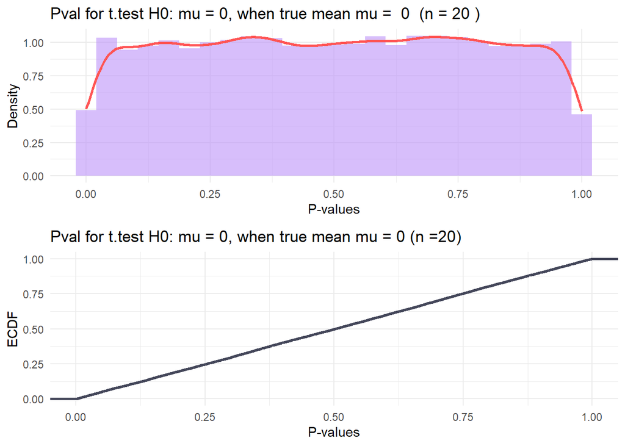

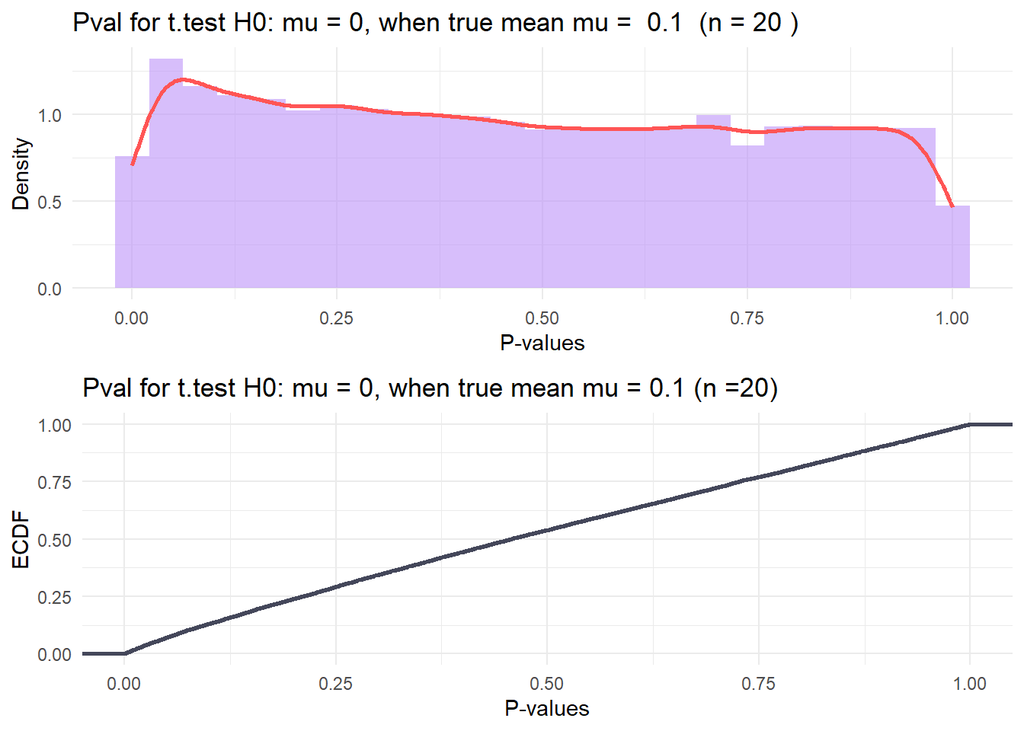

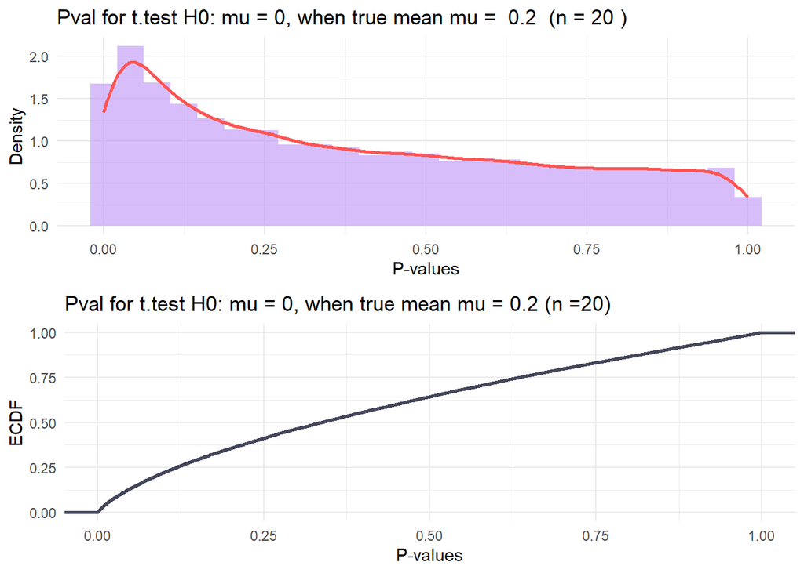

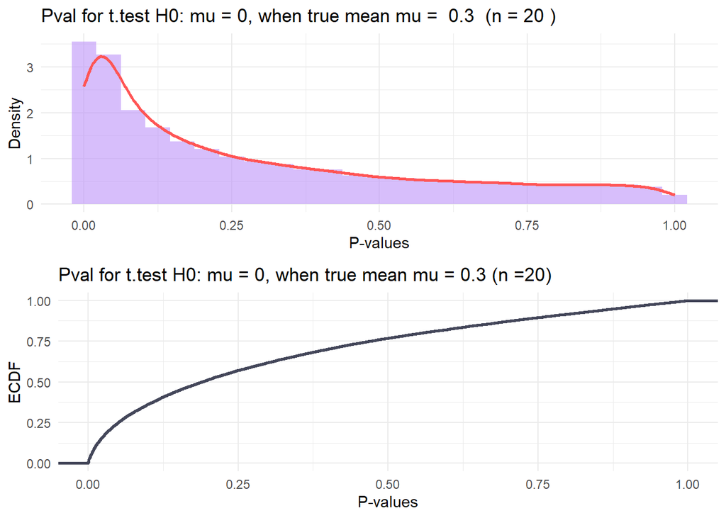

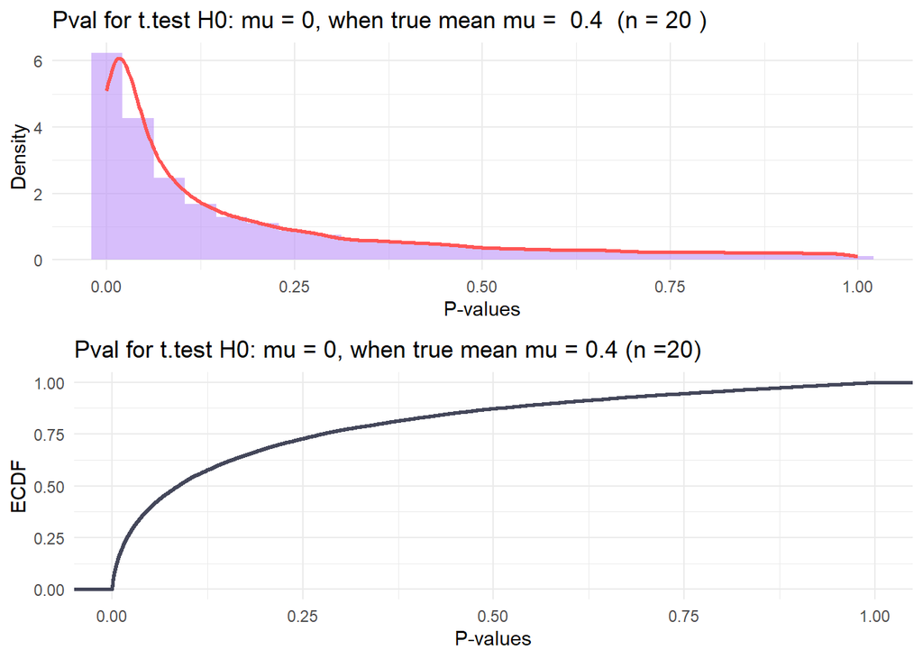

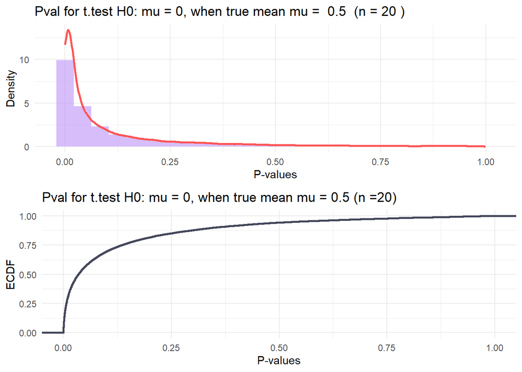

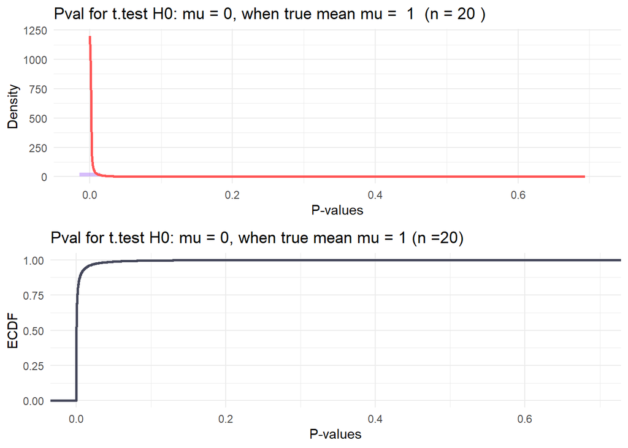

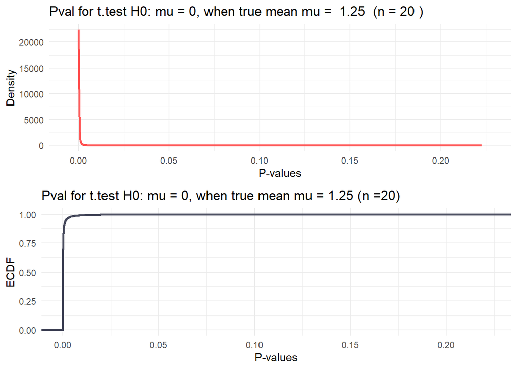

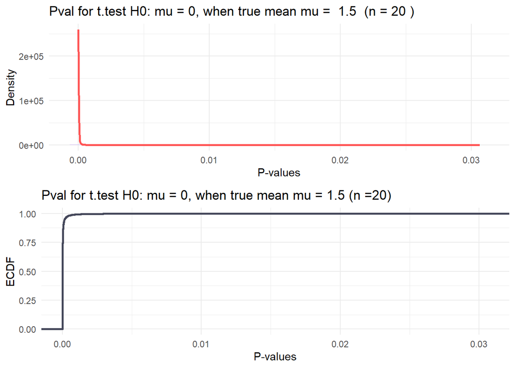

## Conclusion

Under the null hypothesis, by definition the p-value has a uniform distribution. As we move away from the null hypothesis, the p-value skews towards smaller and smaller values. This is obviously desirable : we want the p-value to help us detect effects when they are present, in spite of sampling uncertainty.

If you want to learn more about p-values and statistical inference, how to run simulations like this, and how to do statistics the right way, consider joining my [*Introduction to Biostatistics : Learn Statistics the Right Way!* Course](https://justinbelair.ca/introduction-to-biostatistics/?utm_source=biostatistics&utm_medium=blog&utm_campaign=p-values-distribution) where I teach you everything you need to know about statistics and data analysis.